# Análisis de los datos de accidentes de tráfico en España

A partir datos D.G.T. 2013

Pedro Concejero

2016-04-14

Estudio *provocado* por la carta de la DGT de 2013 informando a propietarios de coches con > 10 años antiguedad

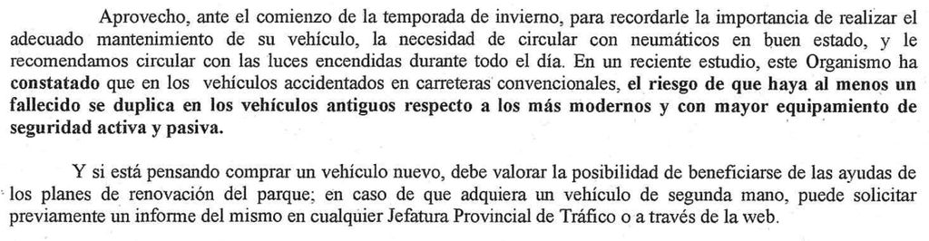

[figure not shown]

¿Reciente estudio? ¿De quién? ¿Dónde está?

Hay varios, que oscilan entre lo ¿burdo?

[figure not shown]

Y otro que publica resultados sin dato alguno que lo soporte

[figure not shown]

Y de ahí que:

[figure not shown]

# ¿Tenemos datos para corroborar / reproducir?

Preguntamos por datos accidentalidad en España y DGT fue muy amable por twitter señalar la siguiente [dirección web para microdatos](https://sedeapl.dgt.gob.es/WEB_IEST_CONSULTA/subcategoria.faces), aunque ¡ojo! en el último momento en que he consultado esta web sólo dispone de datos hasta 2013.

Es interesante señalar que disponemos también de [informes predefinidos](https://sedeapl.dgt.gob.es/WEB_IEST_CONSULTA/buscadorInformePredefinido.faces), básicamente tablas que cruzan variables importantes de clasificación. (Y después de contestar a un captcha…)

# Miremos los datos pero antes…

¡¡ENLACE IMPRESCINDIBLE!! [El “diseño de registro”](https://sedeapl.dgt.gob.es/IEST_INTER/pdfs/disenoRegistro/accidentes/Diseno_Registro_desde_2011.zip)

Ojo por si alguien quiere hacer serie histórica de accidentes que a fecha de escribir esto (31-03-2016, los datos de 2008 y 2010 **no** estaban disponibles en la página DGT)

# Datos de 2013

Descargamos y descomprimimos el .zip y nos encontraremos con 3 csv, tablas separadas para accidentes, personas implicadas, y vehículos.

```r
setwd("C:/Users/pedroc/Desktop/dgt")

csvfiles <- list.files(pattern = glob2rx("*.csv"))

print(csvfiles)
```

```
## [1] "InformePersonalizado_Parque201312_primero.csv"
## [2] "TABLA_ACCVICT_2013.csv"
## [3] "TABLA_PERS_2013.csv"
## [4] "TABLA_VEHIC_2013.csv"
```

# Accidentes en España 2013

```r
accid <- read.table("TABLA_ACCVICT_2013.csv",
                    header = T,
                    sep = ";",
                    colClasses = c(rep("character", 2),
                                   "integer",
                                   "factor",
                                   rep("integer", 4),
                                   "character", # para tener los cod "0xxxx"
                                   rep("numeric", 9),
                                   rep("factor", 18)),
                    quote = "")
dim(accid)
```

```
## [1] 89519    36
```

```r
head(accid)
```

```
##    ID_ACCIDENTE ANIO MES HORA_ACCIDENTE COD_DIASEMANA COD_PROVINCIA
## 1 2013480000644 2013   8          14:00             3            48
## 2 2013480000481 2013   6          18:00             6            48
## 3 2013430023557 2013  11          17:00             2            43
## 4 2013250020735 2013   1          09:00             3            25
## 5 2013080016057 2013  11          22:00             7             8
## 6 2013430023450 2013  10          17:00             3            43
##   COMUNIDAD_AUTONOMA ISLA MUNICIPIO TOTALVICTIMAS TOT_VICTIMAS30D MUERTOS
## 1                 17   NA                       3               3       0
## 2                 17   NA                       1               1       0
## 3                  9   NA                       2               2       0
## 4                  9   NA                       2               2       0
## 5                  9   NA                       2               2       0
## 6                  9   NA                       1               1       1
##   TOTAL_MU30D HERIDOSGRAVES TOTAL_HG30D HERIDOSLEVES TOTAL_HL30D
```

[output cut: 41 more lines]

```r
summary(accid)
```

```
##  ID_ACCIDENTE           ANIO                MES         HORA_ACCIDENTE
##  Length:89519       Length:89519       Min.   : 1.000   14:00  : 3599
##  Class :character   Class :character   1st Qu.: 4.000   13:00  : 3586
##  Mode  :character   Mode  :character   Median : 7.000   12:00  : 3386
##                                        Mean   : 6.646   19:00  : 3319
##                                        3rd Qu.:10.000   18:00  : 3292
##                                        Max.   :12.000   20:00  : 3073
##                                                         (Other):69264
##  COD_DIASEMANA   COD_PROVINCIA   COMUNIDAD_AUTONOMA      ISLA
##  Min.   :1.000   Min.   : 1.00   Min.   : 1.000     Min.   : 71.0
##  1st Qu.:2.000   1st Qu.: 8.00   1st Qu.: 5.000     1st Qu.: 71.0
##  Median :4.000   Median :25.00   Median : 9.000     Median : 73.0
##  Mean   :3.859   Mean   :23.14   Mean   : 8.447     Mean   :193.7
##  3rd Qu.:5.000   3rd Qu.:33.00   3rd Qu.:12.000     3rd Qu.:381.0
##  Max.   :7.000   Max.   :52.00   Max.   :18.000     Max.   :384.0
##                                                     NA's   :83737
##   MUNICIPIO         TOTALVICTIMAS    TOT_VICTIMAS30D     MUERTOS
##  Length:89519       Min.   : 1.000   Min.   : 1.000   Min.   :0.00000
##  Class :character   1st Qu.: 1.000   1st Qu.: 1.000   1st Qu.:0.00000
##  Mode  :character   Median : 1.000   Median : 1.000   Median :0.00000
##                     Mean   : 1.412   Mean   : 1.412   Mean   :0.01663
##                     3rd Qu.: 2.000   3rd Qu.: 2.000   3rd Qu.:0.00000
##                     Max.   :52.000   Max.   :52.000   Max.   :9.00000
##
##   TOTAL_MU30D      HERIDOSGRAVES      TOTAL_HG30D      HERIDOSLEVES
##  Min.   :0.00000   Min.   : 0.0000   Min.   :0.0000   Min.   : 0.000
##  1st Qu.:0.00000   1st Qu.: 0.0000   1st Qu.:0.0000   1st Qu.: 1.000
##  Median :0.00000   Median : 0.0000   Median :0.0000   Median : 1.000
##  Mean   :0.01877   Mean   : 0.1147   Mean   :0.1127   Mean   : 1.281
##  3rd Qu.:0.00000   3rd Qu.: 0.0000   3rd Qu.:0.0000   3rd Qu.: 1.000
##  Max.   :9.00000   Max.   :10.0000   Max.   :9.8197   Max.   :47.000
##
##   TOTAL_HL30D     VEHICULOSIMPLICADOS COD_ZONA  ZONA_AGRUPADA
##  Min.   : 0.000   Min.   : 0.000      1:37148   1:37297
##  1st Qu.: 1.000   1st Qu.: 1.000      2:51455   2:52222
##  Median : 1.000   Median : 2.000      3:  767
##  Mean   : 1.281   Mean   : 1.732      4:  149
##  3rd Qu.: 1.000   3rd Qu.: 2.000
##  Max.   :47.000   Max.   :45.000
##
```

[output cut: 25 more lines]

```
##  14     :74719       :10013    12     :18094     0:32178
##  0      :10130      N:62626    14     :16790     1:52475
##  13     : 2556      S:16880    33     :10835     2: 3983
##  4      :  691                 13     : 6908     3:  883
##  8      :  457                 71     : 6399
##  3      :  279                 15     : 4827
##  (Other):  687                 (Other):25666
##  COD_MEDIDASESPECIALES
##  0:24857
##  1:   24
##  2:   11
##  3: 1061
##  4:63566
##
##
```

```r
table(accid$MUERTOS)
```

```
##
##     0     1     2     3     4     5     9
## 88171  1234    98    11     3     1     1
```

```r
sum(table(accid$MUERTOS[accid$MUERTOS > 0]))
```

```
## [1] 1348
```

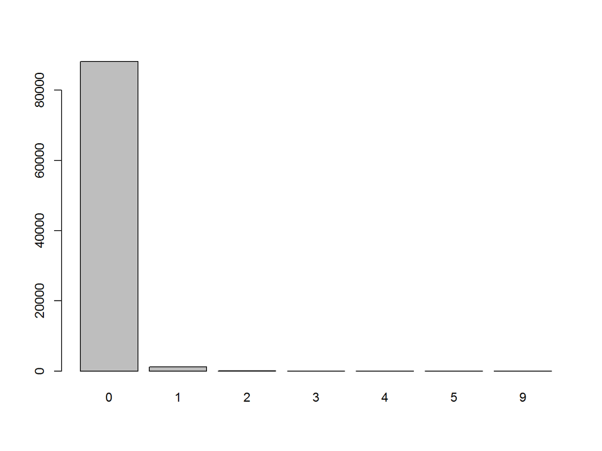

```r
barplot(table(accid$MUERTOS))
```

Leemos los datos de vehículos

```r
vehic <- read.table("TABLA_VEHIC_2013.csv",
                    header = T,
                    sep =",")

dim(vehic)
```

```
## [1] 155004     10
```

```r
summary(vehic)
```

```
##   ID_ACCIDENTE        ID_VEHICULO     ANIO_MATRICULA_VEHICULO
##  Min.   :2.013e+12   Min.   : 1.000   Min.   :1900
##  1st Qu.:2.013e+12   1st Qu.: 1.000   1st Qu.:2003
##  Median :2.013e+12   Median : 1.000   Median :2008
##  Mean   :3.958e+12   Mean   : 1.538   Mean   :4806
##  3rd Qu.:2.013e+12   3rd Qu.: 2.000   3rd Qu.:9999
##  Max.   :2.015e+14   Max.   :45.000   Max.   :9999
##
##  MES_MATRICULA_VEHICULO TIPO_VEHICULO   ESTADO_VEHICULO
##  Min.   : 1.00          Min.   : 1.00   Min.   : 0.000
##  1st Qu.: 6.00          1st Qu.:22.00   1st Qu.: 0.000
##  Median :12.00          Median :22.00   Median : 0.000
##  Mean   :52.36          Mean   :21.85   Mean   : 0.477
##  3rd Qu.:99.00          3rd Qu.:22.00   3rd Qu.: 0.000
##  Max.   :99.00          Max.   :90.00   Max.   :11.000
##                                         NA's   :16684
##  NUMERO_OCUPANTES_VEH MERCANCIAS_PELIGROSAS VEHICULO_INCENDIADO
##  Min.   :  0.0         :68650                : 18413
##  1st Qu.:  1.0        1:    1               N:136507
##  Median :  1.0        2:    1               S:    84
##  Mean   :123.3        3:   25
##  3rd Qu.:  2.0        4:   36
##  Max.   :999.0        N:86291
##  NA's   :7
##       ANIO
##  Min.   :2013
##  1st Qu.:2013
##  Median :2013
##  Mean   :2013
##  3rd Qu.:2013
##  Max.   :2013
##
```

Unas mínimas manipulaciones necesarias:

```r
vehic$ID_ACCIDENTE <- as.character(vehic$ID_ACCIDENTE)
vehic$ID_VEHICULO  <- as.factor(vehic$ID_VEHICULO)
vehic$ANIO_MATRICULA_VEHICULO[vehic$ANIO_MATRICULA_VEHICULO > 2015] <- NA
vehic$ANIO_MATRICULA_VEHICULO  <- as.factor(vehic$ANIO_MATRICULA_VEHICULO)
vehic$MES_MATRICULA_VEHICULO[vehic$MES_MATRICULA_VEHICULO == 99] <- NA
vehic$MES_MATRICULA_VEHICULO  <- as.factor(vehic$MES_MATRICULA_VEHICULO)
vehic$TIPO_VEHICULO  <- as.factor(vehic$TIPO_VEHICULO)
vehic$ESTADO_VEHICULO  <- as.factor(vehic$ESTADO_VEHICULO)
vehic$NUMERO_OCUPANTES_VEH[vehic$NUMERO_OCUPANTES_VEH == 999] <- NA
```

```r
summary(vehic)
```

```
##  ID_ACCIDENTE        ID_VEHICULO    ANIO_MATRICULA_VEHICULO
##  Length:155004      1      :89339   2007   : 8760
##  Class :character   2      :54951   2006   : 8609
##  Mode  :character   3      : 7754   2005   : 7857
##                     4      : 1845   2004   : 6969
##                     5      :  569   2008   : 6500
##                     6      :  206   (Other):61990
##                     (Other):  340   NA's   :54319
##  MES_MATRICULA_VEHICULO TIPO_VEHICULO    ESTADO_VEHICULO
##  7      : 8425          22     :101505   0      :131978
##  6      : 7779          11     : 20701   11     :  5016
##  5      : 7107          43     :  8093   10     :   991
##  3      : 7083          2      :  7574   1      :   201
##  10     : 6503          1      :  6208   2      :    50
##  (Other):41227          41     :  1764   (Other):    84
##  NA's   :76880          (Other):  9159   NA's   : 16684
##  NUMERO_OCUPANTES_VEH MERCANCIAS_PELIGROSAS VEHICULO_INCENDIADO
##  Min.   : 0.000        :68650                : 18413
##  1st Qu.: 1.000       1:    1               N:136507
##  Median : 1.000       2:    1               S:    84
##  Mean   : 1.386       3:   25
##  3rd Qu.: 2.000       4:   36
##  Max.   :61.000       N:86291
##  NA's   :18945
##       ANIO
##  Min.   :2013
##  1st Qu.:2013
##  Median :2013
##  Mean   :2013
##  3rd Qu.:2013
##  Max.   :2013
##
```

35% de los vehículos no tienen antiguedad

¡Tenemos 3 vehículos de 1900! Y 2 anteriores a la II Guerra Mundial (!). Y 54319 NA’s (!!!!!), nada menos que un 35%.

```r
table(vehic$ANIO_MATRICULA_VEHICULO, exclude = NULL)
```

```
##
##  1900  1910  1932  1943  1949  1950  1952  1955  1956  1957  1958  1959
##     3     1     1     1     1     1     1     1     2     1     1     1
##  1961  1962  1963  1964  1965  1966  1968  1969  1970  1971  1972  1973
##     2     1     4     3     2     6     5     5     3     5     6    13
##  1974  1975  1976  1977  1978  1979  1980  1981  1982  1983  1984  1985
##     7     6     9    11    29    27    22    26    33    33    32    57
##  1986  1987  1988  1989  1990  1991  1992  1993  1994  1995  1996  1997
##    97   179   235   366   504   602   863   823  1122  1212  1812  2440
##  1998  1999  2000  2001  2002  2003  2004  2005  2006  2007  2008  2009
##  3421  4798  5183  5525  5263  5846  6969  7857  8609  8760  6500  4802
##  2010  2011  2012  2013  <NA>
##  5033  4805  4193  2504 54319
```

```r
round(table(vehic$ANIO_MATRICULA_VEHICULO, exclude = NULL)/nrow(vehic)*100, digits = 3)
```

```
##
##   1900   1910   1932   1943   1949   1950   1952   1955   1956   1957
##  0.002  0.001  0.001  0.001  0.001  0.001  0.001  0.001  0.001  0.001
##   1958   1959   1961   1962   1963   1964   1965   1966   1968   1969
##  0.001  0.001  0.001  0.001  0.003  0.002  0.001  0.004  0.003  0.003
##   1970   1971   1972   1973   1974   1975   1976   1977   1978   1979
##  0.002  0.003  0.004  0.008  0.005  0.004  0.006  0.007  0.019  0.017
##   1980   1981   1982   1983   1984   1985   1986   1987   1988   1989
##  0.014  0.017  0.021  0.021  0.021  0.037  0.063  0.115  0.152  0.236
##   1990   1991   1992   1993   1994   1995   1996   1997   1998   1999
##  0.325  0.388  0.557  0.531  0.724  0.782  1.169  1.574  2.207  3.095
##   2000   2001   2002   2003   2004   2005   2006   2007   2008   2009
##  3.344  3.564  3.395  3.772  4.496  5.069  5.554  5.651  4.193  3.098
##   2010   2011   2012   2013   <NA>
##  3.247  3.100  2.705  1.615 35.044
```

código 22 son turismos, representan el 65.5% de los datos. Los filtramos porque son el tipo de vehículos en los que nos vamos a concentrar

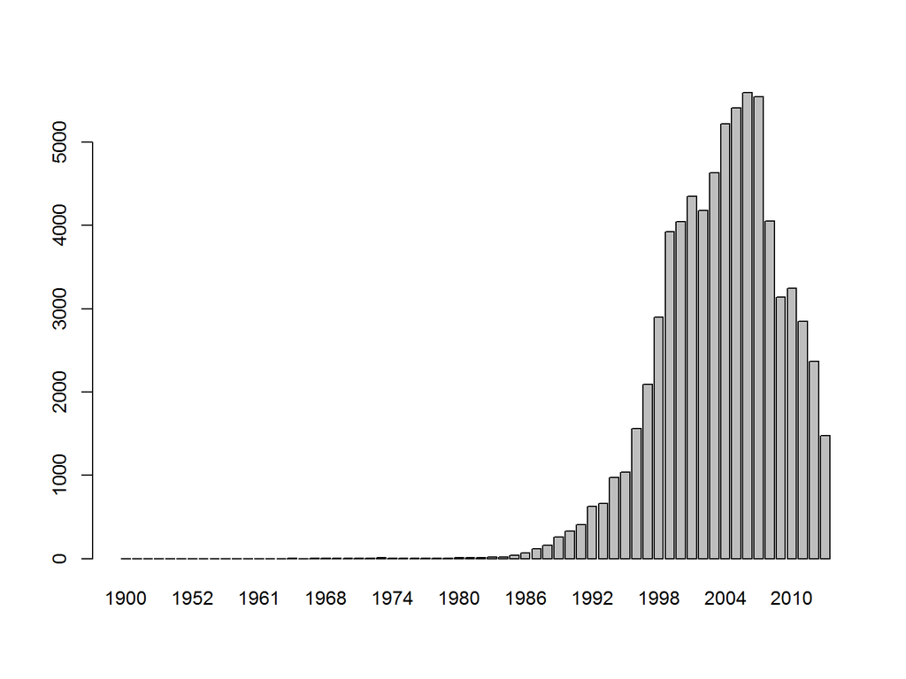

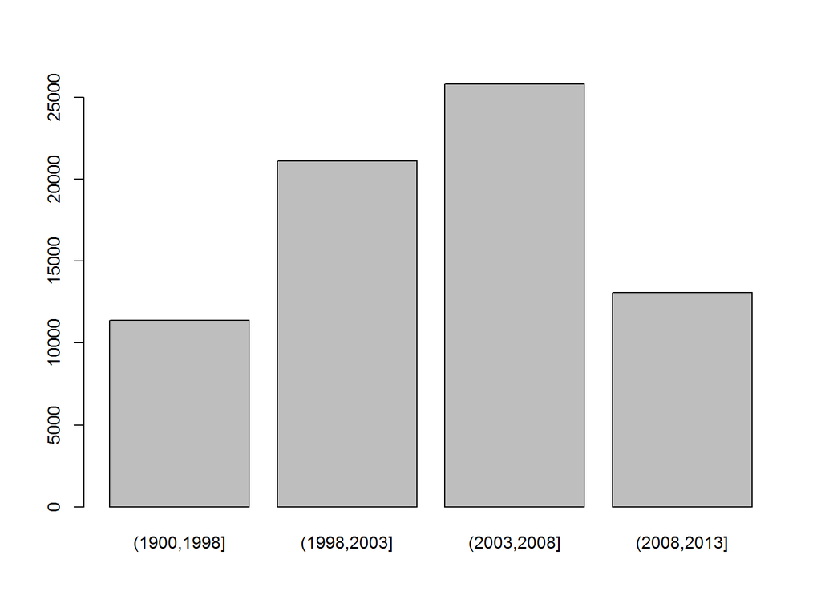

Mezclamos la información de accidentes con la de vehículos. Tenemos ID_ACCIDENTE e ID_VEHICULO que debemos cruzar con misma ID de accidente pero “VEHICULOSIMPLICADOS” en tabla accidentes…

```r
datos <- merge(accid,
               turismos,
               by.x = c("ID_ACCIDENTE", "VEHICULOSIMPLICADOS"),
               by.y = c("ID_ACCIDENTE", "ID_VEHICULO"),
               all.x = F,
               all.y = T)
dim(accid); dim(vehic); dim(datos)
```

```
## [1] 89519    36
```

```
## [1] 155004     10
```

```
## [1] 101505     46
```

(Hay 240 accidentes sin vehículo que no se mezclan porque generan todo NA’s)

```r
summary(datos)
```

```
##  ID_ACCIDENTE       VEHICULOSIMPLICADOS    ANIO.x               MES
##  Length:101505      Length:101505       Length:101505      Min.   : 1.00
##  Class :character   Class :character    Class :character   1st Qu.: 4.00
##  Mode  :character   Mode  :character    Mode  :character   Median : 7.00
##                                                            Mean   : 6.63
##                                                            3rd Qu.:10.00
##                                                            Max.   :12.00
##                                                            NA's   :45701
##  HORA_ACCIDENTE  COD_DIASEMANA   COD_PROVINCIA   COMUNIDAD_AUTONOMA
##  14:00  : 2166   Min.   :1.00    Min.   : 1.00   Min.   : 1.00
##  19:00  : 2133   1st Qu.:2.00    1st Qu.: 8.00   1st Qu.: 5.00
##  13:00  : 2118   Median :4.00    Median :26.00   Median : 9.00
##  18:00  : 1997   Mean   :3.89    Mean   :23.59   Mean   : 8.42
##  12:00  : 1935   3rd Qu.:5.00    3rd Qu.:35.00   3rd Qu.:12.00
##  (Other):45455   Max.   :7.00    Max.   :52.00   Max.   :18.00
##  NA's   :45701   NA's   :45701   NA's   :45701   NA's   :45701
##       ISLA        MUNICIPIO         TOTALVICTIMAS   TOT_VICTIMAS30D
##  Min.   : 71.0   Length:101505      Min.   : 1.00   Min.   : 1.00
##  1st Qu.: 71.0   Class :character   1st Qu.: 1.00   1st Qu.: 1.00
##  Median : 72.0   Mode  :character   Median : 1.00   Median : 1.00
##  Mean   :194.7                      Mean   : 1.51   Mean   : 1.51
##  3rd Qu.:381.0                      3rd Qu.: 2.00   3rd Qu.: 2.00
##  Max.   :384.0                      Max.   :15.00   Max.   :15.00
##  NA's   :97732                      NA's   :45701   NA's   :45701
##     MUERTOS       TOTAL_MU30D    HERIDOSGRAVES    TOTAL_HG30D
##  Min.   :0.00    Min.   :0.00    Min.   : 0.0    Min.   :0.00
##  1st Qu.:0.00    1st Qu.:0.00    1st Qu.: 0.0    1st Qu.:0.00
##  Median :0.00    Median :0.00    Median : 0.0    Median :0.00
##  Mean   :0.01    Mean   :0.02    Mean   : 0.1    Mean   :0.10
##  3rd Qu.:0.00    3rd Qu.:0.00    3rd Qu.: 0.0    3rd Qu.:0.00
##  Max.   :4.00    Max.   :4.00    Max.   :10.0    Max.   :9.82
##  NA's   :45701   NA's   :45701   NA's   :45701   NA's   :45701
##   HERIDOSLEVES    TOTAL_HL30D    COD_ZONA     ZONA_AGRUPADA
##  Min.   : 0.00   Min.   : 0.00   1   :25378   1   :25468
##  1st Qu.: 1.00   1st Qu.: 1.00   2   :29866   2   :30336
##  Median : 1.00   Median : 1.00   3   :  470   NA's:45701
##  Mean   : 1.39   Mean   : 1.39   4   :   90
##  3rd Qu.: 2.00   3rd Qu.: 2.00   NA's:45701
##  Max.   :15.00   Max.   :15.00
##  NA's   :45701   NA's   :45701
```

[output cut: 49 more lines]

```
##  Min.   : 0.000        :41609                :11368
##  1st Qu.: 1.000       1:    0               N:90081
##  Median : 1.000       2:    1               S:   56
##  Mean   : 1.459       3:    0
##  3rd Qu.: 2.000       4:    5
##  Max.   :41.000       N:59890
##  NA's   :11537
##      ANIO.y          edad               gredad
##  Min.   :2013   Min.   :1900    (1900,1998]:11394
##  1st Qu.:2013   1st Qu.:2000    (1998,2003]:21117
##  Median :2013   Median :2004    (2003,2008]:25811
##  Mean   :2013   Mean   :2004    (2008,2013]:13078
##  3rd Qu.:2013   3rd Qu.:2007    NA's       :30105
##  Max.   :2013   Max.   :2013
##                 NA's   :30104
```

Intentamos corrobar hipótesis del “doble riesgo de fallecer”

Datos de frecuencias

```r
table(datos$gredad, datos$MUERTOS)
```

```
##
##                   0     1     2     3     4
##   (1900,1998]  6271   125    13     0     1
##   (1998,2003] 11580   180    19     1     0
##   (2003,2008] 13846   213    26     5     1
##   (2008,2013]  6760    97    10     1     0
```

En proporciones por número de accidentes

```r
round(table(datos$gredad, datos$MUERTOS) / length(unique(datos$ID_ACCIDENTE)), digits = 4) * 10000
```

```
##
##                  0    1    2    3    4
##   (1900,1998]  890   18    2    0    0
##   (1998,2003] 1644   26    3    0    0
##   (2003,2008] 1965   30    4    1    0
##   (2008,2013]  959   14    1    0    0
```

Técnicamente, hay posibilidades de 14 entre 10000 de resultar muerto en accidente en coche de menos 5 años, versus 30 5 a 10 años, 26 de 10 a 15 y 18 para los de más de 15 años.

¡¡YO NO OBSERVO ESA DIFERENCIA QUE MENCIONA FUNDACIÓN LÍNEA DIRECTA!!

¡¡SÍ observo esa relación 2 a 1 en los vehículos de entre 5 y 10 años y 10 y 15 años!!

¿QUÉ PUEDE ESTAR PASANDO?

Simplificamos datos de muertos en accidente (con o sin muertos)

```r
datos$muertos <- cut(datos$MUERTOS,
                     breaks = c(-1, 0, 4),
                     labels = c("0 muertos",
                                ">0 muert"))
table(datos$muertos)
```

```
##
## 0 muertos  >0 muert
##     55062       742
```

Mosaic plots están muy bien en librería vcd

```r
library(vcd)
```

```
## starting httpd help server ...
```

```
##  done
```

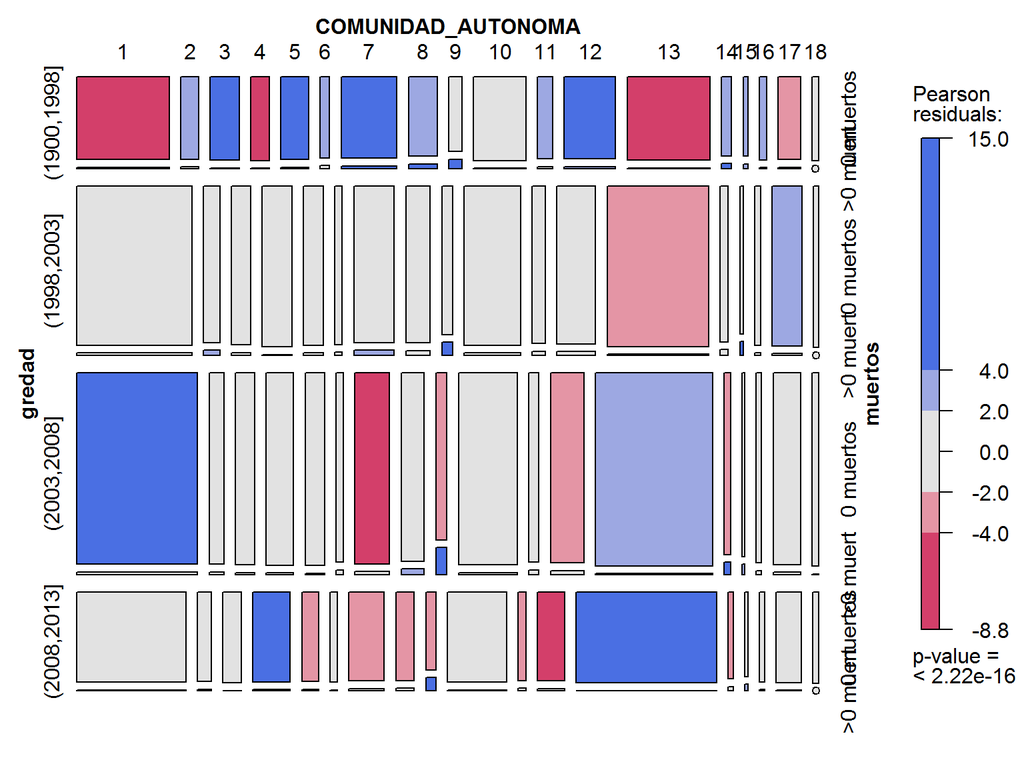

```r
?mosaic
```

- 2 Aragón
- 3 Asturias, Principado de
- 5 Canarias
- 6 Cantabria
- 7 Castilla y León
- 8 Castilla-La Mancha
- 11 Extremadura
- 12 Galicia
- 14 Murcia, Región de
- 15 Navarra, Comunidad Foral de
- 16 Rioja, La

Sin embargo sucede precisamente todo lo contrario en las comunidades autónomas más pobladas:

- 1 Andalucía
- 4 Balears, Illes
- 13 Madrid, Comunidad de
- 17 País Vasco

(Etiquetados como Cataluña sólo tenemos 1741 casos, versus p.ej., 8715 Madrid -> Datos de Cataluña vienen en su mayoría sin código CA)

Insistimos, ¿qué puede estar pasando? El mismo informe de línea directa da una pista esencial

[figure not shown]